# Test du χ 2 d’indépendance

Serigne Fallou Mbacke NGOM

2023-09-14

Nous allons tester l’indépendance, avec une erreur de première espèce choisie égale à 5 %, entre les variables: - TOUX et GRIPPE; - DIARRHEES et VOMISSEMENTS; - FVR et PALUDISME.

### IMPORTER ET NETTOYAE DES DONNEES:

```r
for (i in c("FVR","TOUX", "GRIPPE", "PALUDISME", "DIARRHEES" , "VOMISSEMENTS" ))
  {Clinic_Data[, i]= factor(Clinic_Data[, i])}
for (i in c('FVR', 'TOUX',  'GRIPPE', 'PALUDISME', 'DIARRHEES', 'VOMISSEMENTS'))
{levels(Clinic_Data[,i]) = c(paste(i, "Oui", sep = "_"), paste(i, "Non", sep = "_"))}

data = Clinic_Data[c("FVR","TOUX", "GRIPPE", "PALUDISME", "DIARRHEES" , "VOMISSEMENTS")]
summary(data)
```

```
##       FVR             TOUX             GRIPPE             PALUDISME
##  FVR_Oui:  21   TOUX_Oui:2798   GRIPPE_Oui:2834   PALUDISME_Oui: 736
##  FVR_Non:3702   TOUX_Non: 925   GRIPPE_Non: 889   PALUDISME_Non:2987
##          DIARRHEES              VOMISSEMENTS
##  DIARRHEES_Oui:3652   VOMISSEMENTS_Oui:3201
##  DIARRHEES_Non:  71   VOMISSEMENTS_Non: 522
```

### VISUALISATION DES DONNEES:

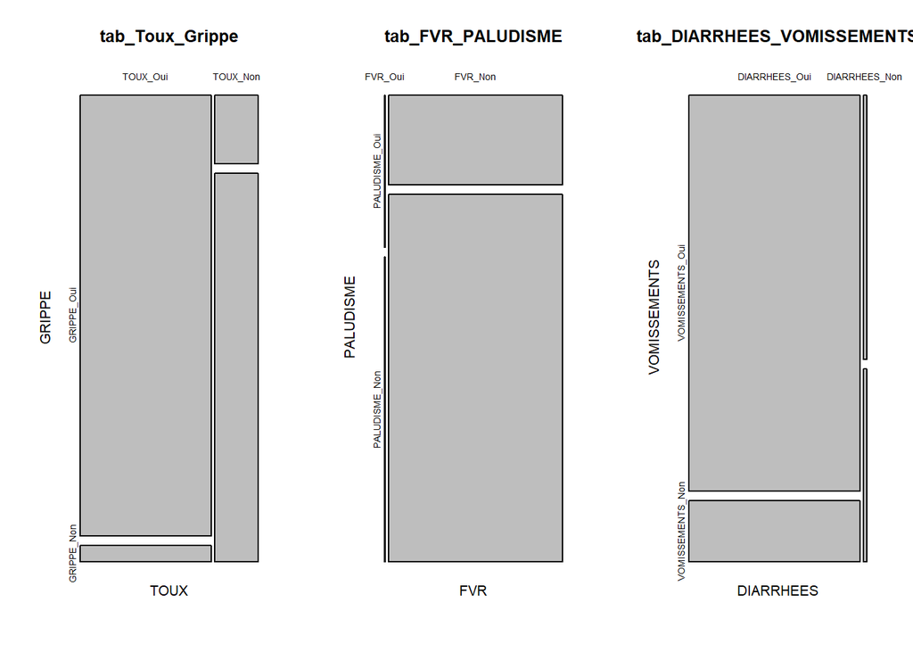

```r
tab_Toux_Grippe <- xtabs(~TOUX+GRIPPE, data=data)
tab_FVR_PALUDISME <- xtabs(~FVR+PALUDISME, data=data)
tab_DIARRHEES_VOMISSEMENTS <- xtabs(~DIARRHEES+VOMISSEMENTS, data=data)

par(mfrow=c(1,3))
plot(tab_Toux_Grippe)
plot(tab_FVR_PALUDISME)
plot(tab_DIARRHEES_VOMISSEMENTS)
```

### Calculer les profils lignes et les profils colonnes (Facultatif):

```r
round(100*prop.table(tab_DIARRHEES_VOMISSEMENTS, margin = 1), 1)
```

```
##                VOMISSEMENTS
## DIARRHEES       VOMISSEMENTS_Oui VOMISSEMENTS_Non
##   DIARRHEES_Oui             86.5             13.5
##   DIARRHEES_Non             57.7             42.3
```

```r
round(100*prop.table(tab_FVR_PALUDISME, margin = 1), 1)
```

```
##          PALUDISME
## FVR       PALUDISME_Oui PALUDISME_Non
##   FVR_Oui          33.3          66.7
##   FVR_Non          19.7          80.3
```

```r
round(100*prop.table(tab_Toux_Grippe, margin = 1), 1)
```

```
##           GRIPPE
## TOUX       GRIPPE_Oui GRIPPE_Non
##   TOUX_Oui       96.3        3.7
##   TOUX_Non       15.0       85.0
```

### Construire le test du χ2:

- TOUX et GRIPPE;

```r
resultat_Toux_Grippe <- chisq.test(tab_Toux_Grippe)
resultat_Toux_Grippe
```

```
##
##  Pearson's Chi-squared test with Yates' continuity correction
##
## data:  tab_Toux_Grippe
## X-squared = 2522.9, df = 1, p-value < 2.2e-16
```

Pour nos données, χ2 obs ≈ 2522.9. La probabilité critique p-value < 2.2e-16. Cette probabilité critique étant inférieure au seuil fixé à 5 %, nous considérons de telles données comme peu probables sous H0 et rejetons cette hypothèse. On considère donc que la GRIPPE dépend de la TOUX.

- DIARRHEES et VOMISSEMENTS;

```r
resultat_DIARRHEES_VOMISSEMENTS <- chisq.test(tab_DIARRHEES_VOMISSEMENTS)
resultat_DIARRHEES_VOMISSEMENTS
```

```
##
##  Pearson's Chi-squared test with Yates' continuity correction
##
## data:  tab_DIARRHEES_VOMISSEMENTS
## X-squared = 45.5, df = 1, p-value = 1.526e-11
```

La probabilité critique p-value < 0.05. Nous rejetons l’hypothèse H0. On considère donc que les VOMISSEMENTS dépendent des DIARRHEES.

- FVR et PALUDISME.

```r
resultat_FVR_PALUDISME <- chisq.test(tab_FVR_PALUDISME)
resultat_FVR_PALUDISME
```

```
##
##  Pearson's Chi-squared test with Yates' continuity correction
##
## data:  tab_FVR_PALUDISME
## X-squared = 1.6653, df = 1, p-value = 0.1969
```

Pour nos données, χ2obs ≈ 1.67 ; La probabilité critique, p-value, indique que, sous H0, et pour un échantillon de même taille, la probabilité d’obtenir une valeur de χ2obs au moins aussi grande que celle-ci est d’environ 19.7%. Cette probabilité critique étant superieure au seuil fixé à 5%, nous considérons de telles données comme fort probables sous H0 et retenons cette hypothèse. On considère donc que le paludisme ne dépend pas de la fievre.

### Calculer les contributions au χ2:

Quand on rejette l’hypothèse d’indépendance, il est intéressant de calculer la contribution des couples de modalités à la statistique du χ2 pour voir les associations entre modalités qui contribuent aux écarts à l’indépendance.

- TOUX et GRIPPE;

```r
round(resultat_Toux_Grippe$expected,1)
```

```
##           GRIPPE
## TOUX       GRIPPE_Oui GRIPPE_Non
##   TOUX_Oui     2129.9      668.1
##   TOUX_Non      704.1      220.9
```

```r
round(100 * resultat_Toux_Grippe$residuals^2 / resultat_Toux_Grippe$statistic, 1)
```

```
##           GRIPPE
## TOUX       GRIPPE_Oui GRIPPE_Non
##   TOUX_Oui        5.9       18.9
##   TOUX_Non       18.0       57.3
```

```r
round(resultat_Toux_Grippe$residuals, 3)
```

```
##           GRIPPE
## TOUX       GRIPPE_Oui GRIPPE_Non
##   TOUX_Oui     12.245    -21.863
##   TOUX_Non    -21.297     38.025
```

Le nombre de patient grippés et presentant des toux est plus important qu’attendu sous H0. De meme que le nombre de patients non grippés et ne presentant pas de toux est beaucoup plus important qu’attebdu sous H0.

- DIARRHEES et VOMISSEMENTS;

```r
round(resultat_DIARRHEES_VOMISSEMENTS$expected,1)
```

```
##                VOMISSEMENTS
## DIARRHEES       VOMISSEMENTS_Oui VOMISSEMENTS_Non
##   DIARRHEES_Oui             3140              512
##   DIARRHEES_Non               61               10
```

```r
round(100 * resultat_DIARRHEES_VOMISSEMENTS$residuals^2 / resultat_DIARRHEES_VOMISSEMENTS$statistic, 1)
```

```
##                VOMISSEMENTS
## DIARRHEES       VOMISSEMENTS_Oui VOMISSEMENTS_Non
##   DIARRHEES_Oui              0.3              1.7
##   DIARRHEES_Non             14.5             88.7
```

```r
round(resultat_DIARRHEES_VOMISSEMENTS$residuals, 3)
```

```
##                VOMISSEMENTS
## DIARRHEES       VOMISSEMENTS_Oui VOMISSEMENTS_Non
##   DIARRHEES_Oui            0.358           -0.886
##   DIARRHEES_Non           -2.566            6.353
```

Le nombre de patient ayant des vomissements et sans diarrhee est plus faible qu’attendu sous H0. De meme que le nombre de patients sans vomissements et ne presentant pas de diarrees est beaucoup plus important qu’attebdu sous H0.